# Week 4 Data Blitz. Confidence Intervals

Gareth Yu and Seongmin Park

October 23, 2026

# 1. Research Question

Do participants who watch videos at different speeds differ in immediate recall of learned material? We believe that faster video speeds will cause worse immediate recall of learned material because they won’t have as much time to encode the material into their memory.

# 2. Packages, Data Import, and Summaries

Your code:

```r
library(ggplot2)
library(Rmisc)
library(summarytools)
library(psych)

filepath <- "https://raw.githubusercontent.com/craigenders/psych250a/main/data/VideoSpeed.csv"

blitz <- read.csv(filepath, stringsAsFactors = TRUE)
dfSummary(blitz)
```

```
Data Frame Summary
blitz
Dimensions: 172 x 7
Duplicates: 0

-----------------------------------------------------------------------------------------------------------------
No   Variable          Stats / Values            Freqs (% of Valid)    Graph                 Valid      Missing
---- ----------------- ------------------------- --------------------- --------------------- ---------- ---------
1    Participant       Mean (sd) : 118 (67.2)    172 distinct values         :   . :   . :   172        0
     [integer]         min < med < max:                                : : : : : : :   : :   (100.0%)   (0.0%)
                       1 < 118.5 < 231                                 : : : : : : : : : :
                       IQR (CV) : 114 (0.6)                            : : : : : : : : : :
                                                                       : : : : : : : : : :

2    Age               Mean (sd) : 20.8 (3)      14 distinct values      : .                 172        0
     [integer]         min < med < max:                                  : :                 (100.0%)   (0.0%)
                       12 < 20 < 41                                      : :
                       IQR (CV) : 2 (0.1)                                : :
                                                                         : : .

3    VideoSpeed        Mean (sd) : 1 (0.8)       0 : 57 (33.1%)        IIIIII                172        0
     [integer]         min < med < max:          1 : 58 (33.7%)        IIIIII                (100.0%)   (0.0%)
                       0 < 1 < 2                 2 : 57 (33.1%)        IIIIII
                       IQR (CV) : 2 (0.8)

4    TwoSpeeds         Min  : 0                  0 :  57 (33.1%)       IIIIII                172        0
     [integer]         Mean : 0.7                1 : 115 (66.9%)       IIIIIIIIIIIII         (100.0%)   (0.0%)
                       Max  : 1

5    ImmediateRecall   Mean (sd) : 60.1 (15.3)   60 distinct values          :               172        0
     [integer]         min < med < max:                                      : : .           (100.0%)   (0.0%)
                       20 < 59 < 93                                        . : : :
                       IQR (CV) : 21.5 (0.3)                             . : : : :
                                                                       . : : : : : : .

6    Delay             Mean (sd) : 9.2 (2.1)     11 distinct values          :               172        0
     [integer]         min < med < max:                                      :               (100.0%)   (0.0%)
                       4 < 9 < 15                                            : .
                       IQR (CV) : 2 (0.2)                                    : : .
                                                                           : : : : . . . :

7    DelayedRecall     Mean (sd) : 52.9 (14.8)   60 distinct values            : :           172        0
     [integer]         min < med < max:                                      : : :           (100.0%)   (0.0%)
                       17 < 54.5 < 93                                        : : :
                       IQR (CV) : 19.5 (0.3)                             . : : : :
                                                                       . : : : : : : .
-----------------------------------------------------------------------------------------------------------------
```

```r
describe(blitz)
```

```
                vars   n   mean    sd median trimmed   mad min max range  skew
Participant        1 172 118.01 67.22  118.5  118.22 85.99   1 231   230  0.01
Age                2 172  20.79  2.99   20.0   20.38  1.48  12  41    29  3.86
VideoSpeed         3 172   1.00  0.82    1.0    1.00  1.48   0   2     2  0.00
TwoSpeeds          4 172   0.67  0.47    1.0    0.71  0.00   0   1     1 -0.71
ImmediateRecall    5 172  60.13 15.26   59.0   60.31 16.31  20  93    73 -0.13
Delay              6 172   9.21  2.11    9.0    8.96  1.48   4  15    11  1.02
DelayedRecall      7 172  52.90 14.84   54.5   53.49 15.57  17  93    76 -0.29
                kurtosis   se
Participant        -1.18 5.13
Age                23.00 0.23
VideoSpeed         -1.51 0.06
TwoSpeeds          -1.50 0.04
ImmediateRecall    -0.48 1.16
Delay               0.79 0.16
DelayedRecall      -0.20 1.13
```

# 3. Factor Conversion and Frequency Distribution

Your code:

```r
blitz$TwoSpeeds <- factor(blitz$TwoSpeeds,
                           levels = c(0, 1),
                           labels = c("1.0x", "1.5x or 2.5x"))
freq(blitz$TwoSpeeds)
```

```
Frequencies
blitz$TwoSpeeds
Type: Factor

                     Freq   % Valid   % Valid Cum.   % Total   % Total Cum.
------------------ ------ --------- -------------- --------- --------------
              1.0x     57     33.14          33.14     33.14          33.14
      1.5x or 2.5x    115     66.86         100.00     66.86         100.00
              <NA>      0                               0.00         100.00
             Total    172    100.00         100.00    100.00         100.00
```

# 4. Full-Sample Confidence Interval

Your code:

```r
CI(blitz$ImmediateRecall, ci = 0.95)
```

```
   upper     mean    lower
62.42467 60.12791 57.83114
```

# 5. Interpretation of the Confidence Limits

A 95% confidence interval of a Immediate Recall shows [57.83, 62.42], indicating that 57.83 is the lowest population mean that could reasonably produce the sample data, and the 62.42 is the highest population mean that could reasonably generate the sample data.

# 6. Simulation of 100 Sample Means

Your prompt and AI’s response:

[output not shown]

AI’s code:

```r
# Set population parameters, sample size, number of samples, and random seed
mu <- 60.13
sigma <- 15.26
N <- 172
n_samples <- 100
set.seed(12345)

# Draw 100 samples from the population and compute their means
sample_means <- replicate(
  n_samples,
  mean(rnorm(N, mean = mu, sd = sigma))
)

# Print the standard deviation of the 100 sample means
print(sd(sample_means))
```

```
[1] 1.246561
```

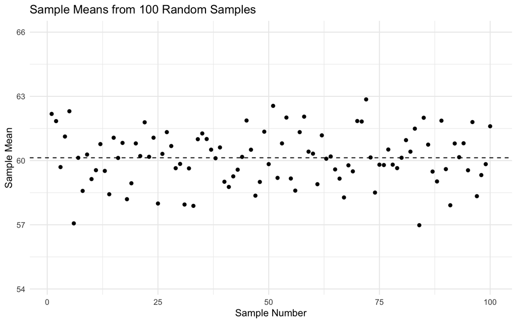

```r
# Create a data frame for plotting
library(ggplot2)
plot_data <- data.frame(
  sample_number = 1:n_samples,
  sample_mean = sample_means
)

# Compute fixed y-axis limits based on ±5 standard errors around mu
y_limits <- c(
  mu - 5 * sigma / sqrt(N),
  mu + 5 * sigma / sqrt(N)
)

# Plot sample means with a reference line at the population mean
ggplot(plot_data, aes(x = sample_number, y = sample_mean)) +
  geom_point(color = "black") +
  geom_hline(yintercept = mu, linetype = "dashed") +
  scale_y_continuous(limits = y_limits) +
  labs(
    x = "Sample Number",
    y = "Sample Mean",
    title = "Sample Means from 100 Random Samples"
  ) +
  theme_minimal()
```

Your inspection of AI’s comments:

AI generated the R code well based on the instruction we provided.

# 7. Explanation of the Standard Error

The standard error of the Immediate Recall mean quantifies the expected variability or sampling error of sample Immediate Recall means from the true population mean. According to the dots and the dashed line, a dot deviated further from the dashed line implies larger standard error while a dot deviated less from the dashed line implies smaller standard error. The Immediate Recall standard error of ‘1.16’ means that in repeated samples of 172 participants from this population, the sample means of Immediate Recall typically deviate from the population mean by about ‘1.16’ points due to random sampling.

# 8. Simulation With 95% Confidence Intervals

Your prompt and AI’s response:

[output not shown]

[output cut: 14 more lines]

```
    )
  ) +
  geom_point(color = "black") +
  geom_hline(yintercept = mu, linetype = "dashed") +
  scale_color_manual(
    values = c("TRUE" = "gray", "FALSE" = "red"),
    guide = "none"
  ) +
  scale_y_continuous(limits = y_limits) +
  labs(
    x = "Sample Number",
    y = "Sample Mean",
    title = "Sample Means from 100 Random Samples"
  ) +
  theme_minimal()
```

AI’s code:

```r
# Set population parameters, sample size, number of samples, and random seed
mu <- 60.13
sigma <- 15.26
N <- 172
n_samples <- 100
set.seed(12345)

# Draw 100 samples from the population and compute their means
sample_means <- replicate(
  n_samples,
  mean(rnorm(N, mean = mu, sd = sigma))
)

# Print the standard deviation of the 100 sample means
print(sd(sample_means))
```

```
[1] 1.246561
```

```r
# Compute 95% confidence interval bounds using the known population sigma
margin_error <- 1.96 * sigma / sqrt(N)
lower_ci <- sample_means - margin_error
upper_ci <- sample_means + margin_error

# Determine whether each interval contains the true population mean
contains_mu <- (lower_ci <= mu) & (upper_ci >= mu)

# Print the number of intervals that contain mu
print(sum(contains_mu))
```

```
[1] 96
```

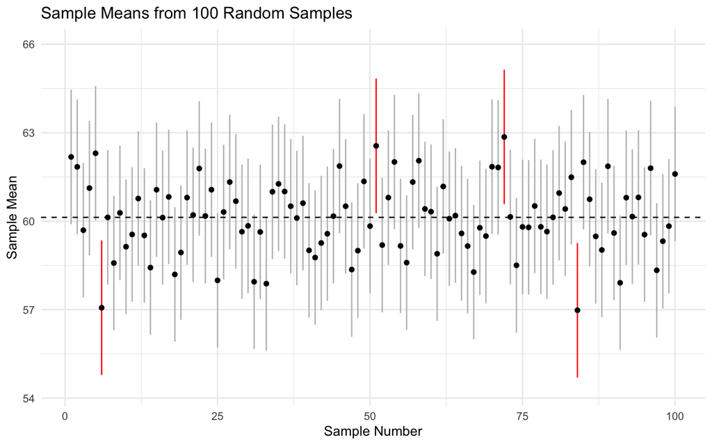

```r
# Create a data frame for plotting
library(ggplot2)
plot_data <- data.frame(
  sample_number = 1:n_samples,
  sample_mean = sample_means,
  lower_ci = lower_ci,
  upper_ci = upper_ci,
  contains_mu = contains_mu
)

# Compute fixed y-axis limits based on ±5 standard errors around mu
y_limits <- c(
  mu - 5 * sigma / sqrt(N),
  mu + 5 * sigma / sqrt(N)
)

# Plot sample means and confidence intervals with a reference line at the population mean
ggplot(plot_data, aes(x = sample_number, y = sample_mean)) +
  geom_linerange(
    aes(
      ymin = lower_ci,
      ymax = upper_ci,
      color = contains_mu
    )
  ) +
  geom_point(color = "black") +
  geom_hline(yintercept = mu, linetype = "dashed") +
  scale_color_manual(
    values = c("TRUE" = "gray", "FALSE" = "red"),
    guide = "none"
  ) +
  scale_y_continuous(limits = y_limits) +
  labs(
    x = "Sample Number",
    y = "Sample Mean",
    title = "Sample Means from 100 Random Samples"
  ) +
  theme_minimal()
```

# 9. Explanation of 95% Confidence

95% confident means that in repeated samples generated from the population, we expect that the intervals would contain the true population mean in 95% of the time. We can see in the graph that when we repeatedly sampled from the known population mean, approximately 95% of the intervals contained the true population mean.

# 10. Descriptives and Confidence Intervals by Group

Your code:

```r
describeBy(ImmediateRecall ~ TwoSpeeds, data = blitz)
```

```
 Descriptive statistics by group
TwoSpeeds: 1.0x
                vars  n  mean    sd median trimmed   mad min max range  skew
ImmediateRecall    1 57 64.93 13.12     65   65.17 14.83  36  91    55 -0.12
                kurtosis   se
ImmediateRecall    -0.58 1.74
------------------------------------------------------------
TwoSpeeds: 1.5x or 2.5x
                vars   n  mean    sd median trimmed   mad min max range  skew
ImmediateRecall    1 115 57.75 15.73     57   57.74 19.27  20  93    73 -0.02
                kurtosis   se
ImmediateRecall    -0.54 1.47
```

```r
group.CI(ImmediateRecall ~ TwoSpeeds, data = blitz, ci = 0.95)
```

```
     TwoSpeeds ImmediateRecall.upper ImmediateRecall.mean ImmediateRecall.lower
1         1.0x              68.41215             64.92982              61.44750
2 1.5x or 2.5x              60.65362             57.74783              54.84203
```

# 11. Differences in Confidence Interval Width

Your prompt and AI’s response:

[output not shown]

# 12. Comparison of the Groups

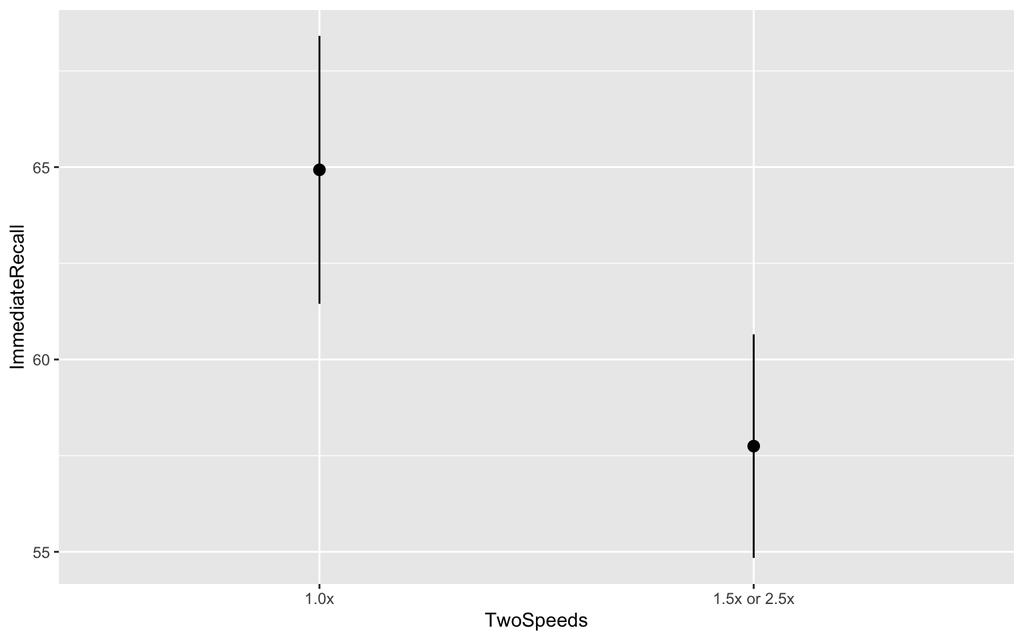

```r
ggplot(blitz, aes(x = TwoSpeeds, y = ImmediateRecall)) +
  stat_summary(fun.data = mean_cl_normal, geom = "pointrange")
```

According to the graph and using “inference by eye” rule for two independent groups, the confindence intervals showed no overlap, indicating that the groups are different since the interval’s overlap are less than 50%. So we can conclude that the groups do differ on the outcome variable.

# 13. Reflection on AI

AI did great for visualization, especially for drawing the graphs!